# STAT 8230 HW4 PROBLEM 1

Connor Armstrong

5/1/2021

1. (24 Psy. Tests) Use the dataset as contained in 24psychtests.csv. Use the raw data (tests 1-24) and the combined 301 students from both schools to carry out factor analysis (both unrotated and varimax rotated). How many factors do you want to model (and why)? Give interpretations of the factors you obtain. Compare the result with the solutions of each school separately.

Import and subset 24psychtests.csv

```r
psytests <- read.csv("C:/Users/conno/OneDrive/Desktop/STAT 8230 - Applied Multivariate Data Analysis/Homework/Homework 4/24psychtests.csv")
columntests24 <- c("V1", "V2", "V3", "V4", "V5", "V6", "V7", "V8", "V9", "V10", "V11", "V12", "V13", "V14", "V15", "V16", "V17", "V18", "V19", "V20", "V21", "V22", "V23", "V24")
psytests24 <- psytests[,columntests24]
```

Determine Number of Factors to Extract

```r
library(nFactors)
```

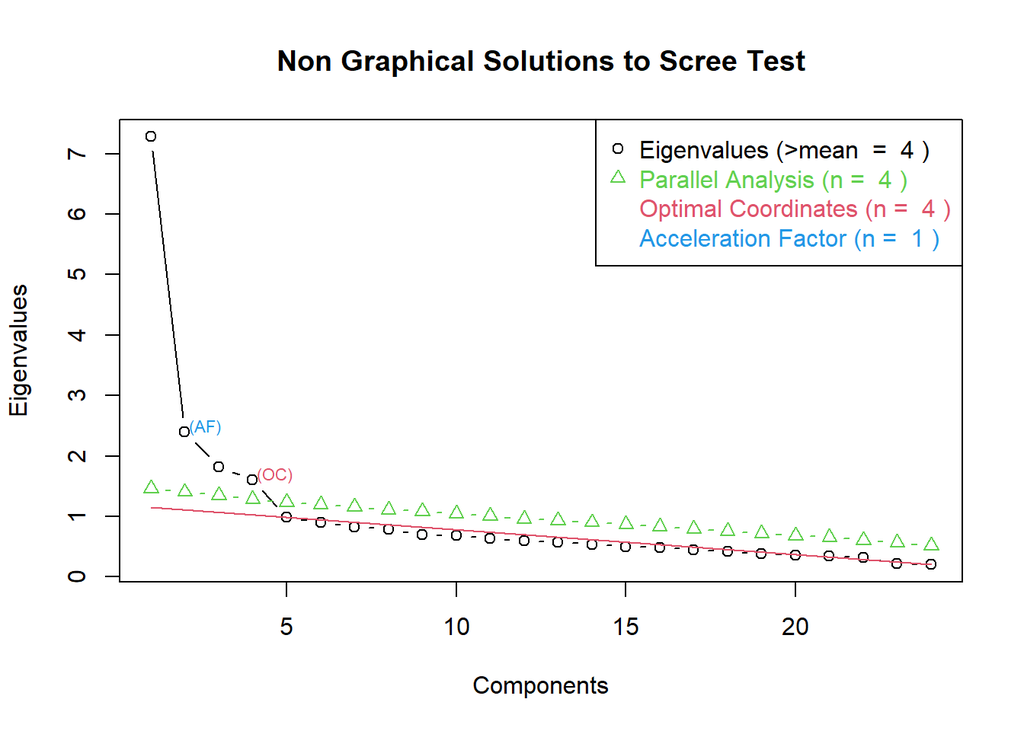

```r
ev <- eigen(cor(psytests24)) # get eigenvalues
ap <- parallel(subject=nrow(psytests24),var=ncol(psytests24),
               rep=100,cent=.05)
nS <- nScree(x=ev$values, aparallel=ap$eigen$qevpea)
plotnScree(nS) #4
```

The nFactors method resulted in an optimum number of factors of 4.  
Factor analysis with 4 factors using varimax rotation and no rotation

```r
psytests24.fa.none <- factanal(psytests24, factors = 4, rotation = "none")
psytests24.fa.varimax <- factanal(psytests24, factors = 4, rotation = "varimax")
```

Construct residual matrix for no rotation factor analysis.

```r
Lambda.none <- psytests24.fa.none$loadings
Psi.none <- diag(psytests24.fa.none$uniquenesses)
S.none <- psytests24.fa.none$correlation
Sigma.none <- Lambda.none %*% t(Lambda.none) + Psi.none
round(S.none - Sigma.none, 6)
```

```
##            V1        V2        V3        V4        V5        V6        V7
## V1   0.000002 -0.040790  0.055135  0.019032 -0.003770  0.044059 -0.000854
## V2  -0.040790  0.000000  0.005657  0.016965  0.009814 -0.009156  0.001054
## V3   0.055135  0.005657 -0.000002  0.027054  0.026993  0.014512 -0.011281
## V4   0.019032  0.016965  0.027054  0.000002 -0.002317  0.014603 -0.008678
## V5  -0.003770  0.009814  0.026993 -0.002317  0.000000 -0.020704 -0.017389
## V6   0.044059 -0.009156  0.014512  0.014603 -0.020704  0.000001  0.019333
## V7  -0.000854  0.001054 -0.011281 -0.008678 -0.017389  0.019333  0.000000
## V8  -0.003003  0.007034  0.005696 -0.000442  0.027658 -0.029052  0.036577
## V9  -0.008216 -0.005000  0.011721  0.021704  0.041492  0.008486 -0.014149
## V10 -0.019109 -0.014902 -0.003408  0.010540  0.012656  0.024243 -0.020185
## V11  0.031685  0.023473 -0.018640  0.004337  0.008550  0.019003  0.009437
## V12 -0.001507  0.004766  0.024096 -0.022229  0.002168 -0.044918  0.016218
## V13  0.057148  0.018537  0.004410  0.022387 -0.010442 -0.012398  0.042538
## V14 -0.019404  0.014896  0.044413 -0.006767 -0.000284  0.011253  0.011518
## V15  0.029665  0.000892 -0.011104  0.026350  0.045272  0.001796 -0.005713
## V16  0.015482  0.014225 -0.003972 -0.029744  0.006329 -0.010795 -0.014003
## V17 -0.004862 -0.014124  0.006972  0.032317 -0.041694  0.004658  0.019955
## V18  0.061488 -0.014354  0.021827  0.029708  0.020203 -0.022213 -0.014219
## V19 -0.056262 -0.022813 -0.034517 -0.040816 -0.025640 -0.032256 -0.017886
## V20 -0.024246  0.005689 -0.032065 -0.013284 -0.016103 -0.011696  0.014019
## V21 -0.067143  0.010899  0.026484 -0.008190 -0.007414 -0.016734  0.001247
## V22 -0.015973  0.010123 -0.075180 -0.006751 -0.018929 -0.019904  0.011000
## V23 -0.002953 -0.016474 -0.033358 -0.007816 -0.009872  0.014696 -0.021160
## V24 -0.035530  0.000390 -0.059483 -0.061212 -0.014658  0.004184 -0.026477
##            V8        V9       V10       V11       V12       V13       V14
## V1  -0.003003 -0.008216 -0.019109  0.031685 -0.001507  0.057148 -0.019404
## V2   0.007034 -0.005000 -0.014902  0.023473  0.004766  0.018537  0.014896
## V3   0.005696  0.011721 -0.003408 -0.018640  0.024096  0.004410  0.044413
## V4  -0.000442  0.021704  0.010540  0.004337 -0.022229  0.022387 -0.006767
## V5   0.027658  0.041492  0.012656  0.008550  0.002168 -0.010442 -0.000284
## V6  -0.029052  0.008486  0.024243  0.019003 -0.044918 -0.012398  0.011253
## V7   0.036577 -0.014149 -0.020185  0.009437  0.016218  0.042538  0.011518
## V8   0.000000 -0.048569 -0.012862  0.007492  0.020876 -0.008833 -0.006560
## V9  -0.048569  0.000001  0.000916 -0.022574  0.001157 -0.016906 -0.018958
## V10 -0.012862  0.000916 -0.000001 -0.023337 -0.003170 -0.038643 -0.012165
## V11  0.007492 -0.022574 -0.023337  0.000000 -0.005131  0.099295  0.012961
## V12  0.020876  0.001157 -0.003170 -0.005131  0.000004  0.043413 -0.008239
## V13 -0.008833 -0.016906 -0.038643  0.099295  0.043413  0.000002  0.046883
## V14 -0.006560 -0.018958 -0.012165  0.012961 -0.008239  0.046883  0.000005
```

[output cut: 45 more lines]

```
## V10 -0.022110  0.028570  0.040217
## V11  0.035442 -0.075860 -0.049286
## V12 -0.000027 -0.004042 -0.000770
## V13 -0.031108 -0.032937 -0.053369
## V14 -0.005462 -0.012274  0.029283
## V15 -0.056631  0.006016 -0.062202
## V16 -0.040997 -0.014607  0.028100
## V17  0.018177  0.025638 -0.088227
## V18  0.006578 -0.072260 -0.007736
## V19  0.064058 -0.006538  0.091122
## V20  0.008297  0.028677  0.026086
## V21  0.011415  0.030615  0.074865
## V22  0.000002  0.070160  0.042075
## V23  0.070160 -0.000001  0.060371
## V24  0.042075  0.060371  0.000001
```

```r
max(round(S.none - Sigma.none, 6))
```

```
## [1] 0.099295
```

Maximum residual is 0.099295, which is close to 0. Numbers close to 0 indicate that our factor model is a good representation of the underlying concept - per example code.  
Construct residual matrix for varimax rotation factor analysis.

```r
Lambda.varimax <- psytests24.fa.varimax$loadings
Psi.varimax <- diag(psytests24.fa.varimax$uniquenesses)
S.varimax <- psytests24.fa.varimax$correlation
Sigma.varimax <- Lambda.varimax %*% t(Lambda.varimax) + Psi.varimax
round(S.varimax - Sigma.varimax, 6)
```

```
##            V1        V2        V3        V4        V5        V6        V7
## V1   0.000002 -0.040790  0.055135  0.019032 -0.003770  0.044059 -0.000854
## V2  -0.040790  0.000000  0.005657  0.016965  0.009814 -0.009156  0.001054
## V3   0.055135  0.005657 -0.000002  0.027054  0.026993  0.014512 -0.011281
## V4   0.019032  0.016965  0.027054  0.000002 -0.002317  0.014603 -0.008678
## V5  -0.003770  0.009814  0.026993 -0.002317  0.000000 -0.020704 -0.017389
## V6   0.044059 -0.009156  0.014512  0.014603 -0.020704  0.000001  0.019333
## V7  -0.000854  0.001054 -0.011281 -0.008678 -0.017389  0.019333  0.000000
## V8  -0.003003  0.007034  0.005696 -0.000442  0.027658 -0.029052  0.036577
## V9  -0.008216 -0.005000  0.011721  0.021704  0.041492  0.008486 -0.014149
## V10 -0.019109 -0.014902 -0.003408  0.010540  0.012656  0.024243 -0.020185
## V11  0.031685  0.023473 -0.018640  0.004337  0.008550  0.019003  0.009437
## V12 -0.001507  0.004766  0.024096 -0.022229  0.002168 -0.044918  0.016218
## V13  0.057148  0.018537  0.004410  0.022387 -0.010442 -0.012398  0.042538
## V14 -0.019404  0.014896  0.044413 -0.006767 -0.000284  0.011253  0.011518
## V15  0.029665  0.000892 -0.011104  0.026350  0.045272  0.001796 -0.005713
## V16  0.015482  0.014225 -0.003972 -0.029744  0.006329 -0.010795 -0.014003
## V17 -0.004862 -0.014124  0.006972  0.032317 -0.041694  0.004658  0.019955
## V18  0.061488 -0.014354  0.021827  0.029708  0.020203 -0.022213 -0.014219
## V19 -0.056262 -0.022813 -0.034517 -0.040816 -0.025640 -0.032256 -0.017886
## V20 -0.024246  0.005689 -0.032065 -0.013284 -0.016103 -0.011696  0.014019
## V21 -0.067143  0.010899  0.026484 -0.008190 -0.007414 -0.016734  0.001247
## V22 -0.015973  0.010123 -0.075180 -0.006751 -0.018929 -0.019904  0.011000
## V23 -0.002953 -0.016474 -0.033358 -0.007816 -0.009872  0.014696 -0.021160
## V24 -0.035530  0.000390 -0.059483 -0.061212 -0.014658  0.004184 -0.026477
##            V8        V9       V10       V11       V12       V13       V14
## V1  -0.003003 -0.008216 -0.019109  0.031685 -0.001507  0.057148 -0.019404
## V2   0.007034 -0.005000 -0.014902  0.023473  0.004766  0.018537  0.014896
## V3   0.005696  0.011721 -0.003408 -0.018640  0.024096  0.004410  0.044413
## V4  -0.000442  0.021704  0.010540  0.004337 -0.022229  0.022387 -0.006767
## V5   0.027658  0.041492  0.012656  0.008550  0.002168 -0.010442 -0.000284
## V6  -0.029052  0.008486  0.024243  0.019003 -0.044918 -0.012398  0.011253
## V7   0.036577 -0.014149 -0.020185  0.009437  0.016218  0.042538  0.011518
## V8   0.000000 -0.048569 -0.012862  0.007492  0.020876 -0.008833 -0.006560
## V9  -0.048569  0.000001  0.000916 -0.022574  0.001157 -0.016906 -0.018958
## V10 -0.012862  0.000916 -0.000001 -0.023337 -0.003170 -0.038643 -0.012165
## V11  0.007492 -0.022574 -0.023337  0.000000 -0.005131  0.099295  0.012961
## V12  0.020876  0.001157 -0.003170 -0.005131  0.000004  0.043413 -0.008239
## V13 -0.008833 -0.016906 -0.038643  0.099295  0.043413  0.000002  0.046883
## V14 -0.006560 -0.018958 -0.012165  0.012961 -0.008239  0.046883  0.000005
```

[output cut: 45 more lines]

```
## V10 -0.022110  0.028570  0.040217
## V11  0.035442 -0.075860 -0.049286
## V12 -0.000027 -0.004042 -0.000770
## V13 -0.031108 -0.032937 -0.053369
## V14 -0.005462 -0.012274  0.029283
## V15 -0.056631  0.006016 -0.062202
## V16 -0.040997 -0.014607  0.028100
## V17  0.018177  0.025638 -0.088227
## V18  0.006578 -0.072260 -0.007736
## V19  0.064058 -0.006538  0.091122
## V20  0.008297  0.028677  0.026086
## V21  0.011415  0.030615  0.074865
## V22  0.000002  0.070160  0.042075
## V23  0.070160 -0.000001  0.060371
## V24  0.042075  0.060371  0.000001
```

```r
max(round(S.varimax - Sigma.varimax, 6))
```

```
## [1] 0.099295
```

Maximum residual is 0.099295, same as no rotation.  
Compare the result with the solutions of each school separately.

```r
library(dplyr)
psytests_1 <- psytests %>% dplyr::filter(Grp == 1)
psytests24_1 <- psytests_1[,c(columntests24)]
psytests_2 <- psytests %>% dplyr::filter(Grp == 2)
psytests24_2 <- psytests_2[,c(columntests24)]
```

Grp=1 Factor analysis with no and varimax rotation

```r
fact_none_1 <- factanal(psytests24_1, 4, rotation = "none")
fact_varimax_1 <- factanal(psytests24_1, 4, rotation = "varimax")

Lambda.none_1 <- fact_none_1$loadings
Psi.none_1 <- diag(fact_none_1$uniquenesses)
S.none_1 <- fact_none_1$correlation
Sigma.none_1 <- Lambda.none_1 %*% t(Lambda.none_1) + Psi.none_1
round(S.none_1 - Sigma.none_1, 6)
```

```
##            V1        V2        V3        V4        V5        V6        V7
## V1   0.000000 -0.044175  0.008733 -0.042699 -0.009368  0.030023  0.011166
## V2  -0.044175 -0.000015 -0.065321  0.064092  0.054931  0.030086 -0.031596
## V3   0.008733 -0.065321  0.000003  0.021832  0.031733  0.004699  0.012630
## V4  -0.042699  0.064092  0.021832  0.000001  0.032767  0.002233 -0.029592
## V5  -0.009368  0.054931  0.031733  0.032767 -0.000006 -0.028862 -0.021747
## V6   0.030023  0.030086  0.004699  0.002233 -0.028862 -0.000002  0.035628
## V7   0.011166 -0.031596  0.012630 -0.029592 -0.021747  0.035628  0.000004
## V8  -0.035657 -0.082047  0.048001  0.022327  0.009303 -0.031404  0.062577
## V9  -0.004110 -0.011483 -0.003005  0.007360  0.043011  0.001857 -0.027762
## V10 -0.024277  0.017169 -0.000860 -0.002870  0.024824  0.003023 -0.014190
## V11  0.024596 -0.014290  0.029755 -0.052029  0.024434  0.072739 -0.048068
## V12  0.022053 -0.011417 -0.023212  0.008478 -0.021400 -0.032464  0.012137
## V13  0.056437 -0.045671  0.068692 -0.017888 -0.024056  0.027418  0.030277
## V14 -0.062559 -0.020561  0.110105  0.001429  0.030998  0.004974  0.000342
## V15 -0.000524  0.004367  0.031033  0.018093  0.040405  0.027612 -0.013563
## V16  0.039764  0.042131  0.049624 -0.045677 -0.043857  0.033982  0.004809
## V17 -0.003081 -0.062090 -0.002552  0.016334 -0.019202 -0.006357  0.018675
## V18  0.018180  0.048497  0.016091  0.065529  0.045526 -0.043146 -0.004525
## V19  0.029011 -0.031778 -0.018525 -0.025208 -0.045417 -0.011310  0.008541
## V20 -0.028684  0.037383 -0.073634 -0.036903 -0.029538 -0.016718  0.033572
## V21 -0.049846  0.012936  0.025783  0.035373 -0.017550 -0.028300  0.014379
## V22  0.021649 -0.024723 -0.125842  0.012501  0.019726 -0.055490 -0.018674
## V23  0.006599  0.029486 -0.048289 -0.008479 -0.030048 -0.022732 -0.038519
## V24 -0.002919  0.048984 -0.106025 -0.007065 -0.024458  0.014651  0.006376
##            V8        V9       V10       V11       V12       V13       V14
## V1  -0.035657 -0.004110 -0.024277  0.024596  0.022053  0.056437 -0.062559
## V2  -0.082047 -0.011483  0.017169 -0.014290 -0.011417 -0.045671 -0.020561
## V3   0.048001 -0.003005 -0.000860  0.029755 -0.023212  0.068692  0.110105
## V4   0.022327  0.007360 -0.002870 -0.052029  0.008478 -0.017888  0.001429
## V5   0.009303  0.043011  0.024824  0.024434 -0.021400 -0.024056  0.030998
## V6  -0.031404  0.001857  0.003023  0.072739 -0.032464  0.027418  0.004974
## V7   0.062577 -0.027762 -0.014190 -0.048068  0.012137  0.030277  0.000342
## V8   0.000000 -0.033914 -0.005823 -0.040766  0.012553  0.014303  0.012439
## V9  -0.033914  0.000007 -0.003371  0.010185  0.005893 -0.010877 -0.032876
## V10 -0.005823 -0.003371  0.000000 -0.011889  0.000988 -0.024689 -0.014829
## V11 -0.040766  0.010185 -0.011889 -0.000001 -0.009550  0.125105  0.064660
## V12  0.012553  0.005893  0.000988 -0.009550  0.000003  0.028610  0.000289
## V13  0.014303 -0.010877 -0.024689  0.125105  0.028610 -0.000001  0.044186
## V14  0.012439 -0.032876 -0.014829  0.064660  0.000289  0.044186  0.000017
```

[output cut: 45 more lines]

```
## V10 -0.010699  0.010515  0.018935
## V11  0.020399 -0.098942 -0.033894
## V12  0.002089  0.050833 -0.005337
## V13 -0.030446 -0.041208 -0.051549
## V14 -0.035396 -0.015581  0.004196
## V15 -0.025414 -0.008840 -0.089193
## V16 -0.068828 -0.016869 -0.006029
## V17 -0.002753  0.020562 -0.043224
## V18 -0.002529 -0.090304  0.043352
## V19  0.068339  0.011350  0.079585
## V20  0.067146  0.081377  0.024669
## V21  0.029178  0.026138  0.057316
## V22 -0.000006  0.072881  0.032544
## V23  0.072881 -0.000001  0.039239
## V24  0.032544  0.039239 -0.000001
```

```r
max(round(S.none_1 - Sigma.none_1, 6))
```

```
## [1] 0.125105
```

```r
Lambda.varimax_1 <- fact_varimax_1$loadings
Psi.varimax_1 <- diag(fact_varimax_1$uniquenesses)
S.varimax_1 <- fact_varimax_1$correlation
Sigma.varimax_1 <- Lambda.varimax_1 %*% t(Lambda.varimax_1) + Psi.varimax_1
round(S.varimax_1 - Sigma.varimax_1, 6)
```

```
##            V1        V2        V3        V4        V5        V6        V7
## V1   0.000000 -0.044175  0.008733 -0.042699 -0.009368  0.030023  0.011166
## V2  -0.044175 -0.000015 -0.065321  0.064092  0.054931  0.030086 -0.031596
## V3   0.008733 -0.065321  0.000003  0.021832  0.031733  0.004699  0.012630
## V4  -0.042699  0.064092  0.021832  0.000001  0.032767  0.002233 -0.029592
## V5  -0.009368  0.054931  0.031733  0.032767 -0.000006 -0.028862 -0.021747
## V6   0.030023  0.030086  0.004699  0.002233 -0.028862 -0.000002  0.035628
## V7   0.011166 -0.031596  0.012630 -0.029592 -0.021747  0.035628  0.000004
## V8  -0.035657 -0.082047  0.048001  0.022327  0.009303 -0.031404  0.062577
## V9  -0.004110 -0.011483 -0.003005  0.007360  0.043011  0.001857 -0.027762
## V10 -0.024277  0.017169 -0.000860 -0.002870  0.024824  0.003023 -0.014190
## V11  0.024596 -0.014290  0.029755 -0.052029  0.024434  0.072739 -0.048068
## V12  0.022053 -0.011417 -0.023212  0.008478 -0.021400 -0.032464  0.012137
## V13  0.056437 -0.045671  0.068692 -0.017888 -0.024056  0.027418  0.030277
## V14 -0.062559 -0.020561  0.110105  0.001429  0.030998  0.004974  0.000342
## V15 -0.000524  0.004367  0.031033  0.018093  0.040405  0.027612 -0.013563
## V16  0.039764  0.042131  0.049624 -0.045677 -0.043857  0.033982  0.004809
## V17 -0.003081 -0.062090 -0.002552  0.016334 -0.019202 -0.006357  0.018675
## V18  0.018180  0.048497  0.016091  0.065529  0.045526 -0.043146 -0.004525
## V19  0.029011 -0.031778 -0.018525 -0.025208 -0.045417 -0.011310  0.008541
## V20 -0.028684  0.037383 -0.073634 -0.036903 -0.029538 -0.016718  0.033572
## V21 -0.049846  0.012936  0.025783  0.035373 -0.017550 -0.028300  0.014379
## V22  0.021649 -0.024723 -0.125842  0.012501  0.019726 -0.055490 -0.018674
## V23  0.006599  0.029486 -0.048289 -0.008479 -0.030048 -0.022732 -0.038519
## V24 -0.002919  0.048984 -0.106025 -0.007065 -0.024458  0.014651  0.006376
##            V8        V9       V10       V11       V12       V13       V14
## V1  -0.035657 -0.004110 -0.024277  0.024596  0.022053  0.056437 -0.062559
## V2  -0.082047 -0.011483  0.017169 -0.014290 -0.011417 -0.045671 -0.020561
## V3   0.048001 -0.003005 -0.000860  0.029755 -0.023212  0.068692  0.110105
## V4   0.022327  0.007360 -0.002870 -0.052029  0.008478 -0.017888  0.001429
## V5   0.009303  0.043011  0.024824  0.024434 -0.021400 -0.024056  0.030998
## V6  -0.031404  0.001857  0.003023  0.072739 -0.032464  0.027418  0.004974
## V7   0.062577 -0.027762 -0.014190 -0.048068  0.012137  0.030277  0.000342
## V8   0.000000 -0.033914 -0.005823 -0.040766  0.012553  0.014303  0.012439
## V9  -0.033914  0.000007 -0.003371  0.010185  0.005893 -0.010877 -0.032876
## V10 -0.005823 -0.003371  0.000000 -0.011889  0.000988 -0.024689 -0.014829
## V11 -0.040766  0.010185 -0.011889 -0.000001 -0.009550  0.125105  0.064660
## V12  0.012553  0.005893  0.000988 -0.009550  0.000003  0.028610  0.000289
## V13  0.014303 -0.010877 -0.024689  0.125105  0.028610 -0.000001  0.044186
## V14  0.012439 -0.032876 -0.014829  0.064660  0.000289  0.044186  0.000017
```

[output cut: 45 more lines]

```
## V10 -0.010699  0.010515  0.018935
## V11  0.020399 -0.098942 -0.033894
## V12  0.002089  0.050833 -0.005337
## V13 -0.030446 -0.041208 -0.051549
## V14 -0.035396 -0.015581  0.004196
## V15 -0.025414 -0.008840 -0.089193
## V16 -0.068828 -0.016869 -0.006029
## V17 -0.002753  0.020562 -0.043224
## V18 -0.002529 -0.090304  0.043352
## V19  0.068339  0.011350  0.079585
## V20  0.067146  0.081377  0.024669
## V21  0.029178  0.026138  0.057316
## V22 -0.000006  0.072881  0.032544
## V23  0.072881 -0.000001  0.039239
## V24  0.032544  0.039239 -0.000001
```

```r
max(round(S.varimax_1 - Sigma.varimax_1, 6))
```

```
## [1] 0.125105
```

Both have maximum residuals of 0.125105, worse than before.  
Grp=2 Factor analysis with no and varimax rotation

```r
fact_varimax_2 <- factanal(psytests24_2, 4, rotation = "varimax")
fact_none_2 <- factanal(psytests24_2, 4, rotation = "none")

Lambda.none_2 <- fact_none_2$loadings
Psi.none_2 <- diag(fact_none_2$uniquenesses)
S.none_2 <- fact_none_2$correlation
Sigma.none_2 <- Lambda.none_2 %*% t(Lambda.none_2) + Psi.none_2
round(S.none_2 - Sigma.none_2, 6)
```

```
##            V1        V2        V3        V4        V5        V6        V7
## V1  -0.000002 -0.026120  0.086479  0.027152  0.012211  0.048277 -0.030286
## V2  -0.026120 -0.000004  0.046320  0.000405 -0.040906 -0.039312  0.010855
## V3   0.086479  0.046320 -0.000001  0.006904  0.021942  0.025311 -0.024310
## V4   0.027152  0.000405  0.006904 -0.000005 -0.000813 -0.015882 -0.006012
## V5   0.012211 -0.040906  0.021942 -0.000813 -0.000001 -0.007437 -0.018291
## V6   0.048277 -0.039312  0.025311 -0.015882 -0.007437 -0.000001  0.002263
## V7  -0.030286  0.010855 -0.024310 -0.006012 -0.018291  0.002263  0.000000
## V8   0.034760  0.060048 -0.018621  0.033985  0.030495 -0.007528  0.012515
## V9   0.011877  0.011809  0.027865  0.005791  0.054198 -0.011747 -0.001775
## V10  0.004577 -0.000079  0.010687 -0.003019  0.007457  0.022455 -0.012398
## V11  0.021237  0.052444 -0.063410  0.060540 -0.008512 -0.047829  0.045308
## V12  0.000195  0.012335  0.068372  0.006062  0.000901 -0.050755  0.013184
## V13  0.061369  0.067868 -0.062735  0.045685 -0.014869 -0.057458  0.046937
## V14 -0.005075  0.022585  0.021226 -0.019571 -0.029724  0.039597  0.014546
## V15  0.040472  0.003586 -0.029268 -0.004883  0.060698 -0.019541 -0.007692
## V16 -0.011844  0.002309 -0.024945 -0.003778  0.046286 -0.038105 -0.018302
## V17 -0.031910  0.046219  0.043055 -0.010852 -0.040367 -0.015185  0.014086
## V18  0.063966 -0.078802  0.046129  0.025635 -0.010653  0.019673 -0.041126
## V19 -0.095642 -0.041533 -0.029652  0.020913 -0.024205 -0.019001 -0.011935
## V20  0.027441 -0.013045 -0.004734  0.027256 -0.006479  0.002187  0.019613
## V21 -0.096711  0.012146  0.007803 -0.042720 -0.004704  0.005490 -0.000860
## V22 -0.048719  0.054709 -0.046618 -0.011053 -0.064185  0.007024  0.038350
## V23 -0.003030 -0.030638 -0.028344 -0.028087  0.014334  0.035970 -0.009320
## V24 -0.001132 -0.071376 -0.026188 -0.025135 -0.033215  0.030626 -0.012625
##            V8        V9       V10       V11       V12       V13       V14
## V1   0.034760  0.011877  0.004577  0.021237  0.000195  0.061369 -0.005075
## V2   0.060048  0.011809 -0.000079  0.052444  0.012335  0.067868  0.022585
## V3  -0.018621  0.027865  0.010687 -0.063410  0.068372 -0.062735  0.021226
## V4   0.033985  0.005791 -0.003019  0.060540  0.006062  0.045685 -0.019571
## V5   0.030495  0.054198  0.007457 -0.008512  0.000901 -0.014869 -0.029724
## V6  -0.007528 -0.011747  0.022455 -0.047829 -0.050755 -0.057458  0.039597
## V7   0.012515 -0.001775 -0.012398  0.045308  0.013184  0.046937  0.014546
## V8   0.000000 -0.046815  0.013424  0.057351 -0.007553 -0.056654 -0.048559
## V9  -0.046815 -0.000001 -0.005488 -0.063785  0.024068 -0.020389 -0.006130
## V10  0.013424 -0.005488  0.000001 -0.009776 -0.007130 -0.022928  0.004959
## V11  0.057351 -0.063785 -0.009776 -0.000001  0.082040  0.157204 -0.041590
## V12 -0.007553  0.024068 -0.007130  0.082040  0.000000  0.129188 -0.054889
## V13 -0.056654 -0.020389 -0.022928  0.157204  0.129188 -0.000003  0.003181
## V14 -0.048559 -0.006130  0.004959 -0.041590 -0.054889  0.003181  0.000002
```

[output cut: 45 more lines]

```
## V10 -0.016818  0.000875  0.017918
## V11  0.032521 -0.068539 -0.049486
## V12  0.009505 -0.059142 -0.064953
## V13 -0.007940 -0.020183 -0.065211
## V14  0.027493 -0.001135  0.048839
## V15 -0.090194  0.027481 -0.006602
## V16 -0.024417 -0.008320  0.010791
## V17  0.009739  0.008940 -0.057694
## V18  0.006274 -0.037586 -0.027792
## V19  0.060825 -0.009557 -0.032125
## V20 -0.058616 -0.003243 -0.053029
## V21 -0.005912  0.026801  0.051493
## V22  0.000000  0.075655  0.048617
## V23  0.075655  0.000001  0.073755
## V24  0.048617  0.073755  0.000000
```

```r
max(round(S.none_2 - Sigma.none_2, 6))
```

```
## [1] 0.157204
```

```r
Lambda.varimax_2 <- fact_varimax_2$loadings
Psi.varimax_2 <- diag(fact_varimax_2$uniquenesses)
S.varimax_2 <- fact_varimax_2$correlation
Sigma.varimax_2 <- Lambda.varimax_2 %*% t(Lambda.varimax_2) + Psi.varimax_2
round(S.varimax_2 - Sigma.varimax_2, 6)
```

```
##            V1        V2        V3        V4        V5        V6        V7
## V1  -0.000002 -0.026120  0.086479  0.027152  0.012211  0.048277 -0.030286
## V2  -0.026120 -0.000004  0.046320  0.000405 -0.040906 -0.039312  0.010855
## V3   0.086479  0.046320 -0.000001  0.006904  0.021942  0.025311 -0.024310
## V4   0.027152  0.000405  0.006904 -0.000005 -0.000813 -0.015882 -0.006012
## V5   0.012211 -0.040906  0.021942 -0.000813 -0.000001 -0.007437 -0.018291
## V6   0.048277 -0.039312  0.025311 -0.015882 -0.007437 -0.000001  0.002263
## V7  -0.030286  0.010855 -0.024310 -0.006012 -0.018291  0.002263  0.000000
## V8   0.034760  0.060048 -0.018621  0.033985  0.030495 -0.007528  0.012515
## V9   0.011877  0.011809  0.027865  0.005791  0.054198 -0.011747 -0.001775
## V10  0.004577 -0.000079  0.010687 -0.003019  0.007457  0.022455 -0.012398
## V11  0.021237  0.052444 -0.063410  0.060540 -0.008512 -0.047829  0.045308
## V12  0.000195  0.012335  0.068372  0.006062  0.000901 -0.050755  0.013184
## V13  0.061369  0.067868 -0.062735  0.045685 -0.014869 -0.057458  0.046937
## V14 -0.005075  0.022585  0.021226 -0.019571 -0.029724  0.039597  0.014546
## V15  0.040472  0.003586 -0.029268 -0.004883  0.060698 -0.019541 -0.007692
## V16 -0.011844  0.002309 -0.024945 -0.003778  0.046286 -0.038105 -0.018302
## V17 -0.031910  0.046219  0.043055 -0.010852 -0.040367 -0.015185  0.014086
## V18  0.063966 -0.078802  0.046129  0.025635 -0.010653  0.019673 -0.041126
## V19 -0.095642 -0.041533 -0.029652  0.020913 -0.024205 -0.019001 -0.011935
## V20  0.027441 -0.013045 -0.004734  0.027256 -0.006479  0.002187  0.019613
## V21 -0.096711  0.012146  0.007803 -0.042720 -0.004704  0.005490 -0.000860
## V22 -0.048719  0.054709 -0.046618 -0.011053 -0.064185  0.007024  0.038350
## V23 -0.003030 -0.030638 -0.028344 -0.028087  0.014334  0.035970 -0.009320
## V24 -0.001132 -0.071376 -0.026188 -0.025135 -0.033215  0.030626 -0.012625
##            V8        V9       V10       V11       V12       V13       V14
## V1   0.034760  0.011877  0.004577  0.021237  0.000195  0.061369 -0.005075
## V2   0.060048  0.011809 -0.000079  0.052444  0.012335  0.067868  0.022585
## V3  -0.018621  0.027865  0.010687 -0.063410  0.068372 -0.062735  0.021226
## V4   0.033985  0.005791 -0.003019  0.060540  0.006062  0.045685 -0.019571
## V5   0.030495  0.054198  0.007457 -0.008512  0.000901 -0.014869 -0.029724
## V6  -0.007528 -0.011747  0.022455 -0.047829 -0.050755 -0.057458  0.039597
## V7   0.012515 -0.001775 -0.012398  0.045308  0.013184  0.046937  0.014546
## V8   0.000000 -0.046815  0.013424  0.057351 -0.007553 -0.056654 -0.048559
## V9  -0.046815 -0.000001 -0.005488 -0.063785  0.024068 -0.020389 -0.006130
## V10  0.013424 -0.005488  0.000001 -0.009776 -0.007130 -0.022928  0.004959
## V11  0.057351 -0.063785 -0.009776 -0.000001  0.082040  0.157204 -0.041590
## V12 -0.007553  0.024068 -0.007130  0.082040  0.000000  0.129188 -0.054889
## V13 -0.056654 -0.020389 -0.022928  0.157204  0.129188 -0.000003  0.003181
## V14 -0.048559 -0.006130  0.004959 -0.041590 -0.054889  0.003181  0.000002
```

[output cut: 45 more lines]

```
## V10 -0.016818  0.000875  0.017918
## V11  0.032521 -0.068539 -0.049486
## V12  0.009505 -0.059142 -0.064953
## V13 -0.007940 -0.020183 -0.065211
## V14  0.027493 -0.001135  0.048839
## V15 -0.090194  0.027481 -0.006602
## V16 -0.024417 -0.008320  0.010791
## V17  0.009739  0.008940 -0.057694
## V18  0.006274 -0.037586 -0.027792
## V19  0.060825 -0.009557 -0.032125
## V20 -0.058616 -0.003243 -0.053029
## V21 -0.005912  0.026801  0.051493
## V22  0.000000  0.075655  0.048617
## V23  0.075655  0.000001  0.073755
## V24  0.048617  0.073755  0.000000
```

```r
max(round(S.varimax_2 - Sigma.varimax_2, 6))
```

```
## [1] 0.157204
```